# Two-Sample Permutation Test

Albert Y. Kim

February 16, 2016

## Running This Document

- Make sure the comma-separated values file `grades.csv` is in the same directory as this file.
- Click on “Knit HTML” and say yes to any prompts to install packages.
- Read over the resulting HTML document.

## Data: Final Exam Scores

- `final`: final exam grade
- `even`: whether the student’s last name had an even or odd # of letters
- `major`: Economics or Other

```r
grades <- read.csv("grades.csv", header=TRUE)
# Look at first 6 rows:
head(grades)
```

```
##       final even     major
## 1 0.9150943  odd Economics
## 2 0.8113208 even     Other
## 3 0.9056604 even     Other
## 4 0.9433962 even     Other
## 5 0.8773585  odd Economics
## 6 0.8396226 even Economics
```

## Even vs Odd Number of Letters

Did students who have an odd number of letters do better on the final that those with an even number of letters? What a silly question; how could there be a relationship between the variables `final` and `even`? We investigate anyways. First the sample sizes and means:

```r
table(grades$even)
```

```
##
## even  odd
##   19   11
```

```r
tapply(grades$final, grades$even, mean)
```

```
##      even       odd
## 0.7323734 0.6595197
```

#### Hypothesis Testing Framework

We lay out the hypothesis testing framework:

- **Population parameter**: $\mu_E - \mu_O$. The true population difference in means.
- **Hypothesis Test**: $H_0: \mu_E - \mu_O = 0$ vs. $H_0: \mu_E - \mu_O \neq 0$. There is no difference vs. there is.
- **Null value**: 0. The value of $\mu_E - \mu_O$ under $H_0$ (assuming $H_0$ is true).
- **Test Statistic**: $T(\vec{X}_E, \vec{X}_O) = \overline{X}_E - \overline{X}_O$. The (random) difference before we observe the data.
- **Observed test statistic**: $T(\vec{x}_E, \vec{x}_O) = \overline{x}_E - \overline{x}_O = 0.732 - 0.660 = 0.0729 = 7.29\%$. The observed difference.

#### Null Distribution

What about the **null distribution** AKA the distribution of the test statistic under $H_0$ AKA the reference distribution used to compute p-values? We note that:

- Under $H_0$, $\mu_E = \mu_O$ i.e. there is no difference.
- Hence the variable `even` is just a meaningless label.
- Hence under $H_0$ we can permute/shuffle the even/odd labels and this won’t matter.

#### Random Permutations

We now proceed to simulate one instance of the test statistic from the null distribution. Note that we observed the following students of the 30 to truly have an even number of letters:

```r
which(grades$even == "even")
```

```
##  [1]  2  3  4  6  7  9 11 13 14 16 17 18 19 21 22 23 24 28 29
```

Now let’s randomly permute/shuffle which of the 30 students will be the evens:

```r
evens_index <- sample(x=30, size=19, replace = FALSE)
evens_index
```

```
##  [1] 19 22 13  3 28 20  8 17 24 14 12 23 30 15  5  9 16  4  7
```

We now compute the simulated difference in means *assuming $H_0$ is true*:

```r
# Pull out final scores:
scores <- grades$final

# Simulated difference of means of evens minus odds
mean(scores[evens_index]) - mean(scores[-evens_index])
```

```
## [1] 0.05389546
```

A difference of 5.39%. We now repeat this many times to build the null distribution.

#### Permutation Test

The code here is similar to the example on page 41, with a few tweaks.

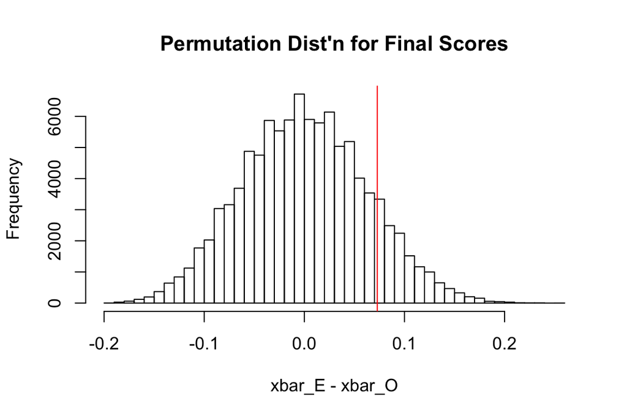

```r
# The observed difference in sample means
sample_means <- tapply(grades$final, grades$even, mean)
observed <- sample_means[1] - sample_means[2]

# Pull out final scores
scores <- grades$final

N <- 10^5 -1                # number of times to repeat this process
result <- rep(0, times=N)   # save the simulated (under H_0) differences here
for(i in 1:N){
  # This step is the random permuting/shuffling of the labels
  evens_index <- sample(30, size=19, replace = FALSE)
  result[i] <- mean(scores[evens_index]) - mean(scores[-evens_index])
}

# Histogram of null distribution and where the observed test statistic lies
hist(result, xlab="xbar_E - xbar_O",
     main = "Permutation Dist'n for Final Scores",
     breaks = 50)
abline(v=observed, col="red")
```

The null distribution is both centered at roughly 0 and it is roughly the most likely value. This makes sense, as under $H_0$ there is no true difference. Differences of -10% and 10% are somewhat likely. Our **observed** difference of 0.0729 is rather plausible. Let’s quantify this extremeness using the p-value by computing the number of simulated values of the test statistic are larger than our observed test statistic:

```r
p_value <- 2 * sum(result >= observed)/(N+1)
p_value
```

```
## [1] 0.25636
```

- we don’t have any evidence to reject $H_0$
- we see no evidence supporting $H_A$

This seems like we’re splitting hairs, but it is an [important distinction](http://blog.minitab.com/blog/understanding-statistics/things-statisticians-say-failure-to-reject-the-null-hypothesis). More on this later.

## Econ Majors

Did economics majors do better than non-econ majors?